# RTSA SS23: Exercise Sheet 8

Martin Memmesheimer

Pranaya Tomar

11.06.2023

**FEEDBACK**

Leave this as it is, we fill it out while grading.

# Exercise 8.1

```r
data <- read.table("fertilizer_seed.txt", header = TRUE)
```

## Part(a)

```r
summary(aov(data$number.of.plants ~ data$Seed * data$Fertilizer))
```

```
##                           Df Sum Sq Mean Sq F value   Pr(>F)
## data$Seed                  2  512.9  256.43  28.283 8.14e-06 ***
## data$Fertilizer            4  449.5  112.37  12.393 0.000119 ***
## data$Seed:data$Fertilizer  8  143.1   17.89   1.973 0.122090
## Residuals                 15  136.0    9.07
## ---
## Signif. codes:  0 '***' 0.001 '**' 0.01 '*' 0.05 '.' 0.1 ' ' 1
```

We see that the interaction is not significant, therefore we accept the nullhypothesis of no interaction.

## Part(b)

```r
seed_1 <- subset(data, Seed = "A-402")
summary(aov(seed_1$number.of.plants ~ seed_1$Fertilizer))
```

```
##                   Df Sum Sq Mean Sq F value Pr(>F)
## seed_1$Fertilizer  4  449.5  112.37   3.547 0.0201 *
## Residuals         25  792.0   31.68
## ---
## Signif. codes:  0 '***' 0.001 '**' 0.01 '*' 0.05 '.' 0.1 ' ' 1
```

```r
seed_2 <- subset(data, Seed = "B-894")
summary(aov(seed_2$number.of.plants ~ seed_2$Fertilizer))
```

```
##                   Df Sum Sq Mean Sq F value Pr(>F)
## seed_2$Fertilizer  4  449.5  112.37   3.547 0.0201 *
## Residuals         25  792.0   31.68
## ---
## Signif. codes:  0 '***' 0.001 '**' 0.01 '*' 0.05 '.' 0.1 ' ' 1
```

```r
seed_3 <- subset(data, Seed = "C-952")
summary(aov(seed_3$number.of.plants ~ seed_3$Fertilizer))
```

```
##                   Df Sum Sq Mean Sq F value Pr(>F)
## seed_3$Fertilizer  4  449.5  112.37   3.547 0.0201 *
## Residuals         25  792.0   31.68
## ---
## Signif. codes:  0 '***' 0.001 '**' 0.01 '*' 0.05 '.' 0.1 ' ' 1
```

Fertilizer is in all 3 significant. Therefore we reject the nullhypothesis in the test.

## Part (c)

```r
summary(aov(data$number.of.plants ~ data$Seed + data$Fertilizer))
```

```
##                 Df Sum Sq Mean Sq F value   Pr(>F)
## data$Seed        2  512.9  256.43  21.130 6.19e-06 ***
## data$Fertilizer  4  449.5  112.37   9.259 0.000131 ***
## Residuals       23  279.1   12.14
## ---
## Signif. codes:  0 '***' 0.001 '**' 0.01 '*' 0.05 '.' 0.1 ' ' 1
```

Seed is significant and we reject the nullhypothesis.

# Exercise 8.2

```r
df <- read.csv("security_log.csv", header=TRUE, sep=';')
System_breakdown = df$System_breakdown
Cyber_attacks = df$Cyber_attacks
```

## Part (a)

```r
lin_model = lm(System_breakdown~Cyber_attacks)
print(summary(lin_model))
```

```
##
## Call:
## lm(formula = System_breakdown ~ Cyber_attacks)
##
## Residuals:
##      Min       1Q   Median       3Q      Max
## -0.58511 -0.30851 -0.03191  0.20745  0.89894
##
## Coefficients:
##               Estimate Std. Error t value Pr(>|t|)
## (Intercept)   -1.42021    0.40196  -3.533  0.00178 **
## Cyber_attacks  0.06915    0.01438   4.809  7.5e-05 ***
## ---
## Signif. codes:  0 '***' 0.001 '**' 0.01 '*' 0.05 '.' 0.1 ' ' 1
##
## Residual standard error: 0.3678 on 23 degrees of freedom
## Multiple R-squared:  0.5013, Adjusted R-squared:  0.4796
## F-statistic: 23.12 on 1 and 23 DF,  p-value: 7.503e-05
```

```r
log_model = glm(System_breakdown~Cyber_attacks,family=binomial(link="logit"))
print(summary(log_model))
```

```
##
## Call:
## glm(formula = System_breakdown ~ Cyber_attacks, family = binomial(link = "logit"))
##
## Deviance Residuals:
##     Min       1Q   Median       3Q      Max
## -1.4674  -0.5196  -0.1466   0.4549   2.4584
##
## Coefficients:
##               Estimate Std. Error z value Pr(>|z|)
## (Intercept)   -14.3861     5.4414  -2.644   0.0082 **
## Cyber_attacks   0.5188     0.1947   2.665   0.0077 **
## ---
## Signif. codes:  0 '***' 0.001 '**' 0.01 '*' 0.05 '.' 0.1 ' ' 1
##
## (Dispersion parameter for binomial family taken to be 1)
##
##     Null deviance: 34.617  on 24  degrees of freedom
## Residual deviance: 18.088  on 23  degrees of freedom
## AIC: 22.088
##
## Number of Fisher Scoring iterations: 5
```

Linear Regression coefficients:

- The y-intercept coefficient (Intercept) = -1.42021 is interpreted as the predicted value of the response variable System_breakdown when no cyber attacks occur.
- The Cyber_attacks coefficient = 0.06915 shows a gentler slope of the regression line showing a gradually increasing linearly relationship between the number of attacks and system breakdown which is not a good fit for the data

## Part (b)

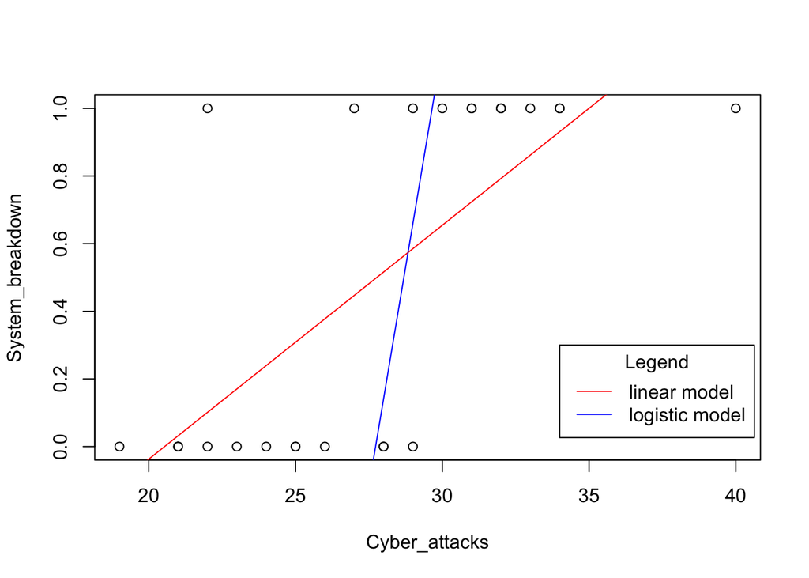

```r
plot(Cyber_attacks, System_breakdown)
abline(lin_model, col='red')
abline(log_model, col='blue')

legend(34, 0.3, inset = .05, legend=c("linear model", "logistic model"), col=c("red","blue"), lty=c(1,1), title="Legend")
```

We observe 2 things about the data in the plot above:

1. The response variable is binary and has only 2 values 0,1
2. The relationship between cyber attack counts and the occurance of a system breakdown is not linear but sigmoidal. We see mostly 0’s till 30 and only 1’s b/w 30 to 40.

Hence logistic regression, which assumes a sigmoidal relationship between the predictors and the probabilities of a binary response variable is a suitable model in this situation.

## Part (c)

```r
prob = predict(log_model, data.frame(Cyber_attacks=26), type = c("response"))
print(c('Probability of system failure = ', prob))
```

```
##                                                                     1
## "Probability of system failure = "                "0.289754677937135"
```

# Exercise 8.3

```r
load("titanic.Rdata")
```

## Part (a)

```r
lin_model = lm(Survival~Class, titanic)
print(summary(lin_model))
```

```
##
## Call:
## lm(formula = Survival ~ Class, data = titanic)
##
## Residuals:
##     Min      1Q  Median      3Q     Max
## -0.6296 -0.2444 -0.2444  0.3704  0.7557
##
## Coefficients:
##             Estimate Std. Error t value Pr(>|t|)
## (Intercept)  0.62963    0.03122  20.165  < 2e-16 ***
## Class2      -0.15680    0.04604  -3.406 0.000689 ***
## Class3      -0.38528    0.03751 -10.270  < 2e-16 ***
## ---
## Signif. codes:  0 '***' 0.001 '**' 0.01 '*' 0.05 '.' 0.1 ' ' 1
##
## Residual standard error: 0.4589 on 884 degrees of freedom
## Multiple R-squared:  0.1141, Adjusted R-squared:  0.1121
## F-statistic: 56.93 on 2 and 884 DF,  p-value: < 2.2e-16
```

```r
prob = predict(lin_model, data.frame(passengers))
print(cbind(Class=passengers$Class, Survival_probability=prob))
```

```
##   Class Survival_probability
## 1     1            0.6296296
## 2     2            0.4728261
## 3     3            0.2443532
## 4     1            0.6296296
## 5     2            0.4728261
## 6     3            0.2443532
```

Looking at the survival probabilities of the 6 passengers it looks like the survival probability decreases as the class of the passenger increases. The is also reflected in the LS estimates Class2 and Class3 which are negative.

## Part (b)

```r
logit_model = glm(Survival~Class+Age+Sex+Siblings+Parents+Fare, titanic, family=binomial(link="logit"))
print(summary(logit_model))
```

```
##
## Call:
## glm(formula = Survival ~ Class + Age + Sex + Siblings + Parents +
##     Fare, family = binomial(link = "logit"), data = titanic)
##
## Deviance Residuals:
##     Min       1Q   Median       3Q      Max
## -2.7560  -0.5950  -0.3942   0.6145   2.4532
##
## Coefficients:
##               Estimate Std. Error z value Pr(>|z|)
## (Intercept)  4.383e+00  4.256e-01  10.300  < 2e-16 ***
## Class2      -1.361e+00  2.718e-01  -5.009 5.47e-07 ***
## Class3      -2.573e+00  2.602e-01  -9.887  < 2e-16 ***
## Age         -4.429e-02  7.778e-03  -5.694 1.24e-08 ***
## Sexmale     -2.776e+00  2.008e-01 -13.824  < 2e-16 ***
## Siblings    -3.819e-01  1.096e-01  -3.485 0.000493 ***
## Parents     -6.866e-02  1.161e-01  -0.591 0.554256
## Fare        -4.403e-06  4.203e-06  -1.048 0.294775
## ---
## Signif. codes:  0 '***' 0.001 '**' 0.01 '*' 0.05 '.' 0.1 ' ' 1
##
## (Dispersion parameter for binomial family taken to be 1)
##
##     Null deviance: 1182.77  on 886  degrees of freedom
## Residual deviance:  781.38  on 879  degrees of freedom
## AIC: 797.38
##
## Number of Fisher Scoring iterations: 5
```

```r
probit_model = glm(Survival~Class+Age+Sex+Siblings+Parents+Fare,titanic, family=binomial(link="probit"))
print(summary(probit_model))
```

```
##
## Call:
## glm(formula = Survival ~ Class + Age + Sex + Siblings + Parents +
##     Fare, family = binomial(link = "probit"), data = titanic)
##
## Deviance Residuals:
##     Min       1Q   Median       3Q      Max
## -2.8906  -0.6093  -0.3978   0.6223   2.4792
##
## Coefficients:
##               Estimate Std. Error z value Pr(>|z|)
## (Intercept)  2.535e+00  2.351e-01  10.782  < 2e-16 ***
## Class2      -7.881e-01  1.561e-01  -5.049 4.45e-07 ***
## Class3      -1.456e+00  1.449e-01 -10.053  < 2e-16 ***
## Age         -2.502e-02  4.383e-03  -5.708 1.14e-08 ***
## Sexmale     -1.635e+00  1.116e-01 -14.651  < 2e-16 ***
## Siblings    -2.197e-01  6.128e-02  -3.585 0.000337 ***
## Parents     -5.191e-02  6.838e-02  -0.759 0.447796
## Fare        -2.292e-06  2.354e-06  -0.973 0.330403
## ---
## Signif. codes:  0 '***' 0.001 '**' 0.01 '*' 0.05 '.' 0.1 ' ' 1
##
## (Dispersion parameter for binomial family taken to be 1)
##
##     Null deviance: 1182.77  on 886  degrees of freedom
## Residual deviance:  783.41  on 879  degrees of freedom
## AIC: 799.41
##
## Number of Fisher Scoring iterations: 5
```

The passenger class is significant as can be seen from the small p value of the dummy variables Class2 and Class3.

## Part (c)

```r
logit_prob = predict(logit_model, data.frame(passengers), type = c("response"))
print(cbind(passengers, Survival_probability=logit_prob))
```

```
##   Class    Sex      Age  Siblings   Parents     Fare Survival_probability
## 1     1   male 29.47144 0.5253664 0.3833145 4044.383           0.51430498
## 2     2   male 29.47144 0.5253664 0.3833145 4044.383           0.21349456
## 3     3   male 29.47144 0.5253664 0.3833145 4044.383           0.07478194
## 4     1 female 29.47144 0.5253664 0.3833145 4044.383           0.94446219
## 5     2 female 29.47144 0.5253664 0.3833145 4044.383           0.81341094
## 6     3 female 29.47144 0.5253664 0.3833145 4044.383           0.56484840
```

```r
probit_prob = predict(probit_model, data.frame(passengers), type = c("response"))
print(cbind(passengers, Survival_probability=probit_prob))
```

```
##   Class    Sex      Age  Siblings   Parents     Fare Survival_probability
## 1     1   male 29.47144 0.5253664 0.3833145 4044.383           0.50721438
## 2     2   male 29.47144 0.5253664 0.3833145 4044.383           0.22065410
## 3     3   male 29.47144 0.5253664 0.3833145 4044.383           0.07519742
## 4     1 female 29.47144 0.5253664 0.3833145 4044.383           0.95087514
## 5     2 female 29.47144 0.5253664 0.3833145 4044.383           0.80657064
## 6     3 female 29.47144 0.5253664 0.3833145 4044.383           0.57815505
```

Both the logit and probit models show a higher survival probability for women when compared to men even across all classes. So the lowest survival probability of a woman in class 3 (0.564840 in logit) is still higher than the highest survival probability of a man in class 1 (0.51430498). So we can say that the data does reflect the women first policy (for children we need to test with data that differs in age).